# DATA624 Knowledge and Visual Analytics Module 1

Omar Pineda

**Principles of Data Visualization and Introduction to ggplot2**

I have provided you with data about the 5,000 fastest growing companies in the US, as compiled by Inc. magazine. lets read this in:

```r
inc <- read.csv("https://raw.githubusercontent.com/charleyferrari/CUNY_DATA_608/master/module1/Data/inc5000_data.csv", header= TRUE)
```

And lets preview this data:

```r
head(inc)
```

|  | Rank | Name | Growth_Rate | Revenue | Industry | Employees | City | State |
| --- | --- | --- | --- | --- | --- | --- | --- | --- |
| 1 | 1 | Fuhu | 421.48 | 1.179e+08 | Consumer Products & Services | 104 | El Segundo | CA |
| 2 | 2 | FederalConference.com | 248.31 | 4.960e+07 | Government Services | 51 | Dumfries | VA |
| 3 | 3 | The HCI Group | 245.45 | 2.550e+07 | Health | 132 | Jacksonville | FL |
| 4 | 4 | Bridger | 233.08 | 1.900e+09 | Energy | 50 | Addison | TX |
| 5 | 5 | DataXu | 213.37 | 8.700e+07 | Advertising & Marketing | 220 | Boston | MA |
| 6 | 6 | MileStone Community Builders | 179.38 | 4.570e+07 | Real Estate | 63 | Austin | TX |

```r
summary(inc)
```

```
      Rank                          Name       Growth_Rate         Revenue
 Min.   :   1   (Add)ventures         :   1   Min.   :  0.340   Min.   :2.000e+06
 1st Qu.:1252   @Properties           :   1   1st Qu.:  0.770   1st Qu.:5.100e+06
 Median :2502   1-Stop Translation USA:   1   Median :  1.420   Median :1.090e+07
 Mean   :2502   110 Consulting        :   1   Mean   :  4.612   Mean   :4.822e+07
 3rd Qu.:3751   11thStreetCoffee.com  :   1   3rd Qu.:  3.290   3rd Qu.:2.860e+07
 Max.   :5000   123 Exteriors         :   1   Max.   :421.480   Max.   :1.010e+10
                (Other)               :4995
                         Industry      Employees                  City          State
 IT Services                 : 733   Min.   :    1.0   New York     : 160   CA     : 701
 Business Products & Services: 482   1st Qu.:   25.0   Chicago      :  90   TX     : 387
 Advertising & Marketing     : 471   Median :   53.0   Austin       :  88   NY     : 311
 Health                      : 355   Mean   :  232.7   Houston      :  76   VA     : 283
 Software                    : 342   3rd Qu.:  132.0   San Francisco:  75   FL     : 282
 Financial Services          : 260   Max.   :66803.0   Atlanta      :  74   IL     : 273
 (Other)                     :2358   NA's   :12        (Other)      :4438   (Other):2764
```

Think a bit on what these summaries mean. Use the space below to add some more relevant non-visual exploratory information you think helps you understand this data:

First, we load our libraries:

```r
library(psych)
library(tidyverse)
```

The psych library helps us pull some additional exploratory information as well as statistics by each industry.

```r
describe(inc)
```

|  | vars | n | mean | sd | median | trimmed | mad | min | max | range | skew | kurtosis | se |
| --- | --- | --- | --- | --- | --- | --- | --- | --- | --- | --- | --- | --- | --- |
| Rank | 1 | 5001 | 2501.64 | 1443.51 | 2.502e+03 | 2501.73 | 1853.25 | 1.0e+00 | 5.0000e+03 | 4.9990e+03 | 0.00 | -1.20 | 20.41 |
| Name* | 2 | 5001 | 2501.00 | 1443.81 | 2.501e+03 | 2501.00 | 1853.25 | 1.0e+00 | 5.0010e+03 | 5.0000e+03 | 0.00 | -1.20 | 20.42 |
| Growth_Rate | 3 | 5001 | 4.61 | 14.12 | 1.420e+00 | 2.14 | 1.22 | 3.4e-01 | 4.2148e+02 | 4.2114e+02 | 12.55 | 242.34 | 0.20 |
| Revenue | 4 | 5001 | 48222535.49 | 240542281.14 | 1.090e+07 | 17334966.26 | 10674720.00 | 2.0e+06 | 1.0100e+10 | 1.0098e+10 | 22.17 | 722.66 | 3401441.44 |
| Industry* | 5 | 5001 | 12.10 | 7.33 | 1.300e+01 | 12.05 | 8.90 | 1.0e+00 | 2.5000e+01 | 2.4000e+01 | -0.10 | -1.18 | 0.10 |
| Employees | 6 | 4989 | 232.72 | 1353.13 | 5.300e+01 | 81.78 | 53.37 | 1.0e+00 | 6.6803e+04 | 6.6802e+04 | 29.81 | 1268.67 | 19.16 |
| City* | 7 | 5001 | 732.00 | 441.12 | 7.610e+02 | 731.74 | 604.90 | 1.0e+00 | 1.5190e+03 | 1.5180e+03 | -0.04 | -1.26 | 6.24 |
| State* | 8 | 5001 | 24.80 | 15.64 | 2.300e+01 | 24.44 | 19.27 | 1.0e+00 | 5.2000e+01 | 5.1000e+01 | 0.12 | -1.46 | 0.22 |

```r
describeBy(inc, inc$Industry)
```

```
 Descriptive statistics by group
group: Advertising & Marketing
```

|  | vars | n | mean | sd | median | trimmed | mad | min | max | range | skew | kurtosis | se |
| --- | --- | --- | --- | --- | --- | --- | --- | --- | --- | --- | --- | --- | --- |
| Rank | 1 | 471 | 2358.72 | 1472.25 | 2.276e+03 | 2334.50 | 1928.86 | 5.0e+00 | 4.9720e+03 | 4.9670e+03 | 0.11 | -1.23 | 67.84 |
| Name* | 2 | 471 | 2535.56 | 1430.96 | 2.559e+03 | 2543.73 | 1786.53 | 1.0e+00 | 4.9820e+03 | 4.9810e+03 | -0.04 | -1.16 | 65.93 |
| Growth_Rate | 3 | 471 | 6.23 | 17.86 | 1.610e+00 | 2.52 | 1.48 | 3.5e-01 | 2.1337e+02 | 2.1302e+02 | 7.11 | 63.37 | 0.82 |
| Revenue | 4 | 471 | 16528662.42 | 29927747.85 | 7.900e+06 | 10135543.77 | 6671700.00 | 2.0e+06 | 3.5680e+08 | 3.5480e+08 | 5.77 | 46.33 | 1378997.83 |
| Industry* | 5 | 471 | 1.00 | 0.00 | 1.000e+00 | 1.00 | 0.00 | 1.0e+00 | 1.0000e+00 | 0.0000e+00 | NaN | NaN | 0.00 |
| Employees | 6 | 471 | 84.35 | 287.40 | 3.700e+01 | 46.84 | 29.65 | 2.0e+00 | 5.6370e+03 | 5.6350e+03 | 15.91 | 295.44 | 13.24 |
| City* | 7 | 471 | 775.90 | 418.55 | 8.920e+02 | 787.05 | 441.81 | 4.0e+00 | 1.5150e+03 | 1.5110e+03 | -0.27 | -1.12 | 19.29 |
| State* | 8 | 471 | 23.38 | 15.23 | 2.100e+01 | 22.70 | 20.76 | 2.0e+00 | 5.0000e+01 | 4.8000e+01 | 0.18 | -1.43 | 0.70 |

```
-----------------------------------------------------------------------------
group: Business Products & Services
```

|  | vars | n | mean | sd | median | trimmed | mad | min | max | range | skew | kurtosis | se |
| --- | --- | --- | --- | --- | --- | --- | --- | --- | --- | --- | --- | --- | --- |
| Rank | 1 | 482 | 2878.04 | 1456.71 | 3066.5 | 2950.80 | 1738.35 | 2.4e+01 | 4.996e+03 | 4.9720e+03 | -0.34 | -1.08 | 66.35 |
| Name* | 2 | 482 | 2559.63 | 1366.73 | 2612.5 | 2574.88 | 1693.87 | 3.0e+00 | 5.001e+03 | 4.9980e+03 | -0.06 | -1.08 | 62.25 |
| Growth_Rate | 3 | 482 | 3.52 | 8.70 | 1.1 | 1.55 | 0.85 | 3.4e-01 | 8.585e+01 | 8.5510e+01 | 5.52 | 35.74 | 0.40 |
| Revenue | 4 | 482 | 54705186.72 | 187054186.71 | 9850000.0 | 17096113.99 | 9414510.00 | 2.0e+06 | 2.400e+09 | 2.3980e+09 | 8.03 | 80.11 | 8520084.74 |
| Industry* | 5 | 482 | 2.00 | 0.00 | 2.0 | 2.00 | 0.00 | 2.0e+00 | 2.000e+00 | 0.0000e+00 | NaN | NaN | 0.00 |
| Employees | 6 | 480 | 244.49 | 1519.52 | 49.0 | 84.02 | 48.93 | 4.0e+00 | 3.200e+04 | 3.1996e+04 | 19.17 | 394.75 | 69.36 |
| City* | 7 | 482 | 742.78 | 445.28 | 763.0 | 742.63 | 612.31 | 1.0e+00 | 1.505e+03 | 1.5040e+03 | -0.01 | -1.29 | 20.28 |
| State* | 8 | 482 | 24.62 | 16.08 | 22.5 | 24.14 | 21.50 | 2.0e+00 | 5.000e+01 | 4.8000e+01 | 0.16 | -1.50 | 0.73 |

```
-----------------------------------------------------------------------------
group: Computer Hardware
```

|  | vars | n | mean | sd | median | trimmed | mad | min | max | range | skew | kurtosis | se |
| --- | --- | --- | --- | --- | --- | --- | --- | --- | --- | --- | --- | --- | --- |
| Rank | 1 | 44 | 3008.07 | 1.333980e+03 | 3.1535e+03 | 3081.36 | 1568.59 | 1.6e+01 | 4.9910e+03 | 4.97500e+03 | -0.35 | -0.91 | 201.11 |
| Name* | 2 | 44 | 2326.64 | 1.631020e+03 | 2.7115e+03 | 2286.92 | 2678.32 | 2.9e+01 | 4.9960e+03 | 4.96700e+03 | 0.05 | -1.53 | 245.88 |
| Growth_Rate | 3 | 44 | 4.09 | 1.654000e+01 | 1.0400e+00 | 1.26 | 0.73 | 3.5e-01 | 1.1068e+02 | 1.10330e+02 | 6.08 | 36.18 | 2.49 |
| Revenue | 4 | 44 | 270129545.45 | 1.517136e+09 | 2.2350e+07 | 33902777.78 | 20237490.00 | 3.8e+06 | 1.0100e+10 | 1.00962e+10 | 6.18 | 37.05 | 228716786.74 |
| Industry* | 5 | 44 | 3.00 | 0.000000e+00 | 3.0000e+00 | 3.00 | 0.00 | 3.0e+00 | 3.0000e+00 | 0.00000e+00 | NaN | NaN | 0.00 |
| Employees | 6 | 44 | 220.77 | 1.016740e+03 | 4.5500e+01 | 60.39 | 30.39 | 6.0e+00 | 6.8000e+03 | 6.79400e+03 | 6.15 | 36.85 | 153.28 |
| City* | 7 | 44 | 766.64 | 4.197300e+02 | 7.6750e+02 | 775.83 | 562.65 | 5.6e+01 | 1.5110e+03 | 1.45500e+03 | -0.19 | -1.28 | 63.28 |
| State* | 8 | 44 | 16.59 | 1.553000e+01 | 1.0500e+01 | 14.44 | 8.15 | 4.0e+00 | 4.9000e+01 | 4.50000e+01 | 1.09 | -0.41 | 2.34 |

```
-----------------------------------------------------------------------------
group: Construction
```

|  | vars | n | mean | sd | median | trimmed | mad | min | max | range | skew | kurtosis | se |
| --- | --- | --- | --- | --- | --- | --- | --- | --- | --- | --- | --- | --- | --- |
| Rank | 1 | 187 | 2642.24 | 1.38790e+03 | 2.701e+03 | 2666.26 | 1663.48 | 5.0e+01 | 4.978e+03 | 4.9280e+03 | -0.09 | -1.09 | 101.49 |
| Name* | 2 | 187 | 2422.98 | 1.47808e+03 | 2.359e+03 | 2412.42 | 2008.92 | 6.0e+00 | 4.973e+03 | 4.9670e+03 | 0.08 | -1.35 | 108.09 |
| Growth_Rate | 3 | 187 | 3.37 | 6.78000e+00 | 1.300e+00 | 1.76 | 1.04 | 3.5e-01 | 5.328e+01 | 5.2930e+01 | 4.50 | 23.26 | 0.50 |
| Revenue | 4 | 187 | 70450802.14 | 3.99588e+08 | 1.400e+07 | 20820529.80 | 13936440.00 | 2.1e+06 | 4.700e+09 | 4.6979e+09 | 10.03 | 105.01 | 29220768.60 |
| Industry* | 5 | 187 | 4.00 | 0.00000e+00 | 4.000e+00 | 4.00 | 0.00 | 4.0e+00 | 4.000e+00 | 0.0000e+00 | NaN | NaN | 0.00 |
| Employees | 6 | 187 | 155.61 | 5.89230e+02 | 4.700e+01 | 66.42 | 43.00 | 3.0e+00 | 6.549e+03 | 6.5460e+03 | 8.98 | 86.58 | 43.09 |
| City* | 7 | 187 | 746.48 | 4.60430e+02 | 7.630e+02 | 743.03 | 612.31 | 2.0e+00 | 1.513e+03 | 1.5110e+03 | -0.04 | -1.32 | 33.67 |
| State* | 8 | 187 | 25.11 | 1.52100e+01 | 2.300e+01 | 24.88 | 19.27 | 1.0e+00 | 5.000e+01 | 4.9000e+01 | 0.14 | -1.47 | 1.11 |

```
-----------------------------------------------------------------------------
group: Consumer Products & Services
```

|  | vars | n | mean | sd | median | trimmed | mad | min | max | range | skew | kurtosis | se |
| --- | --- | --- | --- | --- | --- | --- | --- | --- | --- | --- | --- | --- | --- |
| Rank | 1 | 203 | 2193.77 | 1524.26 | 2.056e+03 | 2133.40 | 1940.72 | 1.0e+00 | 4.9800e+03 | 4.9790e+03 | 0.24 | -1.28 | 106.98 |
| Name* | 2 | 203 | 2534.44 | 1486.89 | 2.611e+03 | 2529.65 | 1991.13 | 2.8e+01 | 4.9930e+03 | 4.9650e+03 | 0.01 | -1.29 | 104.36 |
| Growth_Rate | 3 | 203 | 8.78 | 33.86 | 1.820e+00 | 3.38 | 1.82 | 3.5e-01 | 4.2148e+02 | 4.2113e+02 | 9.74 | 109.11 | 2.38 |
| Revenue | 4 | 203 | 73676847.29 | 424610810.98 | 9.400e+06 | 14198773.01 | 9043860.00 | 2.0e+06 | 4.6000e+09 | 4.5980e+09 | 8.90 | 82.86 | 29801836.56 |
| Industry* | 5 | 203 | 5.00 | 0.00 | 5.000e+00 | 5.00 | 0.00 | 5.0e+00 | 5.0000e+00 | 0.0000e+00 | NaN | NaN | 0.00 |
| Employees | 6 | 203 | 223.96 | 1214.94 | 3.400e+01 | 47.55 | 35.58 | 1.0e+00 | 1.3200e+04 | 1.3199e+04 | 8.82 | 82.48 | 85.27 |
| City* | 7 | 203 | 687.57 | 451.27 | 6.240e+02 | 678.32 | 643.45 | 4.0e+00 | 1.5100e+03 | 1.5060e+03 | 0.09 | -1.40 | 31.67 |
| State* | 8 | 203 | 23.02 | 15.89 | 2.000e+01 | 22.30 | 22.24 | 2.0e+00 | 5.0000e+01 | 4.8000e+01 | 0.27 | -1.47 | 1.11 |

```
-----------------------------------------------------------------------------
group: Education
```

|  | vars | n | mean | sd | median | trimmed | mad | min | max | range | skew | kurtosis | se |
| --- | --- | --- | --- | --- | --- | --- | --- | --- | --- | --- | --- | --- | --- |
| Rank | 1 | 83 | 2758.00 | 1467.85 | 2852.0 | 2798.88 | 1848.80 | 3.5e+01 | 4.948e+03 | 4.913e+03 | -0.23 | -1.26 | 161.12 |
| Name* | 2 | 83 | 2634.02 | 1455.64 | 2751.0 | 2676.93 | 1770.22 | 1.7e+01 | 4.926e+03 | 4.909e+03 | -0.19 | -1.23 | 159.78 |
| Growth_Rate | 3 | 83 | 3.64 | 9.06 | 1.2 | 1.78 | 0.98 | 3.6e-01 | 7.063e+01 | 7.027e+01 | 5.68 | 36.02 | 0.99 |
| Revenue | 4 | 83 | 13726506.02 | 21729220.99 | 6800000.0 | 8431343.28 | 5337360.00 | 2.0e+06 | 1.457e+08 | 1.437e+08 | 3.73 | 16.36 | 2385091.86 |
| Industry* | 5 | 83 | 6.00 | 0.00 | 6.0 | 6.00 | 0.00 | 6.0e+00 | 6.000e+00 | 0.000e+00 | NaN | NaN | 0.00 |
| Employees | 6 | 83 | 92.59 | 136.42 | 44.0 | 60.81 | 40.03 | 1.0e+00 | 8.500e+02 | 8.490e+02 | 3.13 | 11.60 | 14.97 |
| City* | 7 | 83 | 809.37 | 453.59 | 929.0 | 816.99 | 541.15 | 2.5e+01 | 1.505e+03 | 1.480e+03 | -0.15 | -1.31 | 49.79 |
| State* | 8 | 83 | 24.58 | 14.59 | 23.0 | 24.43 | 19.27 | 2.0e+00 | 4.700e+01 | 4.500e+01 | -0.02 | -1.46 | 1.60 |

```
-----------------------------------------------------------------------------
group: Energy
```

|  | vars | n | mean | sd | median | trimmed | mad | min | max | range | skew | kurtosis | se |
| --- | --- | --- | --- | --- | --- | --- | --- | --- | --- | --- | --- | --- | --- |
| Rank | 1 | 109 | 2.03822e+03 | 1564.15 | 1.843e+03 | 1955.26 | 1922.93 | 4.0e+00 | 4.9670e+03 | 4.9630e+03 | 0.39 | -1.22 | 149.82 |
| Name* | 2 | 109 | 2.59694e+03 | 1476.85 | 2.829e+03 | 2623.53 | 1973.34 | 3.4e+01 | 4.9360e+03 | 4.9020e+03 | -0.16 | -1.38 | 141.46 |
| Growth_Rate | 3 | 109 | 9.60000e+00 | 25.26 | 2.080e+00 | 4.52 | 2.27 | 3.5e-01 | 2.3308e+02 | 2.3273e+02 | 6.69 | 53.94 | 2.42 |
| Revenue | 4 | 109 | 1.26345e+08 | 290953924.53 | 2.940e+07 | 61451685.39 | 34099800.00 | 2.1e+06 | 1.9000e+09 | 1.8979e+09 | 4.51 | 23.20 | 27868331.67 |
| Industry* | 5 | 109 | 7.00000e+00 | 0.00 | 7.000e+00 | 7.00 | 0.00 | 7.0e+00 | 7.0000e+00 | 0.0000e+00 | NaN | NaN | 0.00 |
| Employees | 6 | 109 | 2.42540e+02 | 454.36 | 7.000e+01 | 135.34 | 80.06 | 2.0e+00 | 2.5010e+03 | 2.4990e+03 | 3.37 | 12.16 | 43.52 |
| City* | 7 | 109 | 6.94870e+02 | 455.39 | 6.040e+02 | 683.78 | 581.18 | 2.0e+00 | 1.5180e+03 | 1.5160e+03 | 0.14 | -1.21 | 43.62 |
| State* | 8 | 109 | 2.70000e+01 | 16.07 | 2.800e+01 | 27.37 | 25.20 | 1.0e+00 | 5.2000e+01 | 5.1000e+01 | -0.17 | -1.51 | 1.54 |

```
-----------------------------------------------------------------------------
group: Engineering
```

|  | vars | n | mean | sd | median | trimmed | mad | min | max | range | skew | kurtosis | se |
| --- | --- | --- | --- | --- | --- | --- | --- | --- | --- | --- | --- | --- | --- |
| Rank | 1 | 74 | 2733.09 | 1333.07 | 2.6065e+03 | 2729.02 | 1811.74 | 5.33e+02 | 4.935e+03 | 4.402e+03 | 0.04 | -1.30 | 154.97 |
| Name* | 2 | 74 | 2556.45 | 1448.61 | 2.4925e+03 | 2594.83 | 1926.64 | 5.80e+01 | 4.984e+03 | 4.926e+03 | -0.23 | -1.25 | 168.40 |
| Growth_Rate | 3 | 74 | 1.98 | 1.87 | 1.3500e+00 | 1.62 | 1.10 | 3.60e-01 | 8.540e+00 | 8.180e+00 | 1.81 | 2.94 | 0.22 |
| Revenue | 4 | 74 | 34222972.97 | 86336302.54 | 1.2100e+07 | 17226666.67 | 11193630.00 | 2.10e+06 | 6.887e+08 | 6.866e+08 | 6.15 | 42.24 | 10036391.31 |
| Industry* | 5 | 74 | 8.00 | 0.00 | 8.0000e+00 | 8.00 | 0.00 | 8.00e+00 | 8.000e+00 | 0.000e+00 | NaN | NaN | 0.00 |
| Employees | 6 | 74 | 276.15 | 1166.04 | 6.4000e+01 | 93.62 | 57.08 | 1.10e+01 | 1.000e+04 | 9.989e+03 | 7.84 | 62.36 | 135.55 |
| City* | 7 | 74 | 829.19 | 451.57 | 9.2900e+02 | 842.42 | 475.91 | 2.30e+01 | 1.499e+03 | 1.476e+03 | -0.31 | -1.23 | 52.49 |
| State* | 8 | 74 | 25.54 | 16.11 | 2.3000e+01 | 25.27 | 23.72 | 2.00e+00 | 5.000e+01 | 4.800e+01 | 0.05 | -1.44 | 1.87 |

```
-----------------------------------------------------------------------------
group: Environmental Services
```

|  | vars | n | mean | sd | median | trimmed | mad | min | max | range | skew | kurtosis | se |
| --- | --- | --- | --- | --- | --- | --- | --- | --- | --- | --- | --- | --- | --- |
| Rank | 1 | 51 | 2699.12 | 1.32508e+03 | 2.517e+03 | 2693.17 | 1676.82 | 5.32e+02 | 5.000e+03 | 4.4680e+03 | 0.05 | -1.23 | 185.55 |
| Name* | 2 | 51 | 2185.14 | 1.41811e+03 | 1.612e+03 | 2134.71 | 1776.15 | 5.70e+01 | 4.933e+03 | 4.8760e+03 | 0.32 | -1.06 | 198.58 |
| Growth_Rate | 3 | 51 | 2.07 | 2.04000e+00 | 1.410e+00 | 1.62 | 1.13 | 3.40e-01 | 8.540e+00 | 8.2000e+00 | 1.77 | 2.25 | 0.29 |
| Revenue | 4 | 51 | 51741176.47 | 1.95171e+08 | 1.250e+07 | 18953658.54 | 13343400.00 | 2.10e+06 | 1.400e+09 | 1.3979e+09 | 6.46 | 41.66 | 27329403.43 |
| Industry* | 5 | 51 | 9.00 | 0.00000e+00 | 9.000e+00 | 9.00 | 0.00 | 9.00e+00 | 9.000e+00 | 0.0000e+00 | NaN | NaN | 0.00 |
| Employees | 6 | 51 | 199.12 | 7.42180e+02 | 6.700e+01 | 79.98 | 57.82 | 4.00e+00 | 5.347e+03 | 5.3430e+03 | 6.54 | 42.39 | 103.93 |
| City* | 7 | 51 | 815.00 | 3.96010e+02 | 8.870e+02 | 828.76 | 419.58 | 6.60e+01 | 1.514e+03 | 1.4480e+03 | -0.24 | -0.94 | 55.45 |
| State* | 8 | 51 | 27.88 | 1.54400e+01 | 3.100e+01 | 28.39 | 17.79 | 2.00e+00 | 5.000e+01 | 4.8000e+01 | -0.32 | -1.29 | 2.16 |

```
-----------------------------------------------------------------------------
group: Financial Services
```

|  | vars | n | mean | sd | median | trimmed | mad | min | max | range | skew | kurtosis | se |
| --- | --- | --- | --- | --- | --- | --- | --- | --- | --- | --- | --- | --- | --- |
| Rank | 1 | 260 | 2352.78 | 1434.57 | 2.4255e+03 | 2339.24 | 1898.47 | 7.0e+00 | 4.9990e+03 | 4.992e+03 | 0.04 | -1.24 | 88.97 |
| Name* | 2 | 260 | 2440.78 | 1491.03 | 2.3770e+03 | 2430.45 | 1943.69 | 2.3e+01 | 4.9690e+03 | 4.946e+03 | 0.01 | -1.25 | 92.47 |
| Growth_Rate | 3 | 260 | 5.44 | 14.92 | 1.4800e+00 | 2.53 | 1.30 | 3.4e-01 | 1.7404e+02 | 1.737e+02 | 7.64 | 71.54 | 0.93 |
| Revenue | 4 | 260 | 50580384.62 | 101167777.04 | 1.5550e+07 | 27006730.77 | 17494680.00 | 2.0e+06 | 9.5910e+08 | 9.571e+08 | 4.69 | 29.64 | 6274159.19 |
| Industry* | 5 | 260 | 10.00 | 0.00 | 1.0000e+01 | 10.00 | 0.00 | 1.0e+01 | 1.0000e+01 | 0.000e+00 | NaN | NaN | 0.00 |
| Employees | 6 | 260 | 183.43 | 302.83 | 7.0000e+01 | 109.74 | 80.06 | 5.0e+00 | 1.8290e+03 | 1.824e+03 | 3.05 | 9.96 | 18.78 |
| City* | 7 | 260 | 718.68 | 445.68 | 7.8350e+02 | 718.45 | 581.92 | 1.3e+01 | 1.4880e+03 | 1.475e+03 | -0.10 | -1.33 | 27.64 |
| State* | 8 | 260 | 25.32 | 15.52 | 2.4500e+01 | 25.09 | 21.50 | 2.0e+00 | 5.0000e+01 | 4.800e+01 | 0.05 | -1.46 | 0.96 |

```
-----------------------------------------------------------------------------
group: Food & Beverage
```

|  | vars | n | mean | sd | median | trimmed | mad | min | max | range | skew | kurtosis | se |
| --- | --- | --- | --- | --- | --- | --- | --- | --- | --- | --- | --- | --- | --- |
| Rank | 1 | 131 | 2649.44 | 1.37280e+03 | 2.666e+03 | 2655.41 | 1604.17 | 1.9e+01 | 4.997e+03 | 4.978e+03 | -0.03 | -1.03 | 119.94 |
| Name* | 2 | 131 | 2614.92 | 1.40811e+03 | 2.614e+03 | 2624.75 | 1648.65 | 5.0e+00 | 4.997e+03 | 4.992e+03 | -0.06 | -1.17 | 123.03 |
| Growth_Rate | 3 | 131 | 3.64 | 1.01100e+01 | 1.320e+00 | 1.70 | 1.04 | 3.4e-01 | 1.001e+02 | 9.976e+01 | 7.28 | 62.18 | 0.88 |
| Revenue | 4 | 131 | 98559541.98 | 4.20552e+08 | 1.860e+07 | 31424761.90 | 20015100.00 | 2.0e+06 | 4.500e+09 | 4.498e+09 | 9.08 | 89.61 | 36743797.81 |
| Industry* | 5 | 131 | 11.00 | 0.00000e+00 | 1.100e+01 | 11.00 | 0.00 | 1.1e+01 | 1.100e+01 | 0.000e+00 | NaN | NaN | 0.00 |
| Employees | 6 | 129 | 510.94 | 1.25018e+03 | 6.500e+01 | 181.02 | 75.61 | 3.0e+00 | 7.681e+03 | 7.678e+03 | 3.65 | 14.32 | 110.07 |
| City* | 7 | 131 | 694.91 | 4.64550e+02 | 7.480e+02 | 686.98 | 639.00 | 2.0e+00 | 1.517e+03 | 1.515e+03 | 0.06 | -1.41 | 40.59 |
| State* | 8 | 131 | 22.22 | 1.55800e+01 | 1.800e+01 | 21.26 | 19.27 | 4.0e+00 | 5.000e+01 | 4.600e+01 | 0.36 | -1.39 | 1.36 |

```
-----------------------------------------------------------------------------
group: Government Services
```

|  | vars | n | mean | sd | median | trimmed | mad | min | max | range | skew | kurtosis | se |
| --- | --- | --- | --- | --- | --- | --- | --- | --- | --- | --- | --- | --- | --- |
| Rank | 1 | 202 | 2087.87 | 1.44384e+03 | 1.815e+03 | 2004.98 | 1734.64 | 2.0e+00 | 4.9950e+03 | 4.9930e+03 | 0.39 | -1.00 | 101.59 |
| Name* | 2 | 202 | 2408.13 | 1.51407e+03 | 2.386e+03 | 2390.50 | 1997.06 | 7.0e+00 | 4.9910e+03 | 4.9840e+03 | 0.10 | -1.27 | 106.53 |
| Growth_Rate | 3 | 202 | 7.24 | 2.21200e+01 | 2.110e+00 | 3.34 | 2.02 | 3.5e-01 | 2.4831e+02 | 2.4796e+02 | 8.34 | 79.74 | 1.56 |
| Revenue | 4 | 202 | 29748019.80 | 1.03202e+08 | 1.145e+07 | 15246296.30 | 9933420.00 | 2.0e+06 | 1.4000e+09 | 1.3980e+09 | 11.74 | 151.19 | 7261265.77 |
| Industry* | 5 | 202 | 12.00 | 0.00000e+00 | 1.200e+01 | 12.00 | 0.00 | 1.2e+01 | 1.2000e+01 | 0.0000e+00 | NaN | NaN | 0.00 |
| Employees | 6 | 202 | 129.63 | 1.82640e+02 | 7.100e+01 | 89.24 | 62.27 | 6.0e+00 | 1.3520e+03 | 1.3460e+03 | 3.78 | 17.94 | 12.85 |
| City* | 7 | 202 | 702.90 | 4.72340e+02 | 6.120e+02 | 698.02 | 604.90 | 9.0e+00 | 1.5040e+03 | 1.4950e+03 | 0.11 | -1.32 | 33.23 |
| State* | 8 | 202 | 29.80 | 1.77000e+01 | 3.600e+01 | 31.02 | 16.31 | 2.0e+00 | 5.0000e+01 | 4.8000e+01 | -0.30 | -1.61 | 1.25 |

```
-----------------------------------------------------------------------------
group: Health
```

|  | vars | n | mean | sd | median | trimmed | mad | min | max | range | skew | kurtosis | se |
| --- | --- | --- | --- | --- | --- | --- | --- | --- | --- | --- | --- | --- | --- |
| Rank | 1 | 355 | 2415.75 | 1452.98 | 2.319e+03 | 2394.57 | 1879.94 | 3.0e+00 | 4.9850e+03 | 4.982e+03 | 0.10 | -1.23 | 77.12 |
| Name* | 2 | 355 | 2514.49 | 1389.87 | 2.678e+03 | 2520.99 | 1654.58 | 1.4e+01 | 4.9980e+03 | 4.984e+03 | -0.06 | -1.11 | 73.77 |
| Growth_Rate | 3 | 355 | 4.86 | 15.42 | 1.570e+00 | 2.36 | 1.39 | 3.5e-01 | 2.4545e+02 | 2.451e+02 | 11.62 | 167.91 | 0.82 |
| Revenue | 4 | 355 | 50319436.62 | 196752099.87 | 1.140e+07 | 19647719.30 | 11564280.00 | 2.0e+06 | 2.7000e+09 | 2.698e+09 | 10.23 | 119.53 | 10442517.21 |
| Industry* | 5 | 355 | 13.00 | 0.00 | 1.300e+01 | 13.00 | 0.00 | 1.3e+01 | 1.3000e+01 | 0.000e+00 | NaN | NaN | 0.00 |
| Employees | 6 | 354 | 232.85 | 490.96 | 7.100e+01 | 119.92 | 74.13 | 2.0e+00 | 4.3900e+03 | 4.388e+03 | 4.69 | 26.99 | 26.09 |
| City* | 7 | 355 | 778.99 | 446.45 | 7.940e+02 | 784.31 | 566.35 | 1.9e+01 | 1.5080e+03 | 1.489e+03 | -0.10 | -1.28 | 23.70 |
| State* | 8 | 355 | 24.79 | 15.09 | 2.300e+01 | 24.50 | 19.27 | 2.0e+00 | 5.1000e+01 | 4.900e+01 | 0.12 | -1.38 | 0.80 |

```
-----------------------------------------------------------------------------
group: Human Resources
```

|  | vars | n | mean | sd | median | trimmed | mad | min | max | range | skew | kurtosis | se |
| --- | --- | --- | --- | --- | --- | --- | --- | --- | --- | --- | --- | --- | --- |
| Rank | 1 | 196 | 2426.40 | 1390.71 | 2.3855e+03 | 2405.63 | 1756.14 | 1.37e+02 | 4.9940e+03 | 4.8570e+03 | 0.08 | -1.20 | 99.34 |
| Name* | 2 | 196 | 2462.59 | 1439.79 | 2.3585e+03 | 2455.18 | 1755.40 | 5.60e+01 | 4.9270e+03 | 4.8710e+03 | 0.05 | -1.24 | 102.84 |
| Growth_Rate | 3 | 196 | 3.30 | 4.62 | 1.5200e+00 | 2.20 | 1.32 | 3.50e-01 | 2.6960e+01 | 2.6610e+01 | 2.82 | 8.68 | 0.33 |
| Revenue | 4 | 196 | 47173979.59 | 88457811.97 | 1.1450e+07 | 24317088.61 | 12231450.00 | 2.00e+06 | 5.3770e+08 | 5.3570e+08 | 3.10 | 10.30 | 6318415.14 |
| Industry* | 5 | 196 | 14.00 | 0.00 | 1.4000e+01 | 14.00 | 0.00 | 1.40e+01 | 1.4000e+01 | 0.0000e+00 | NaN | NaN | 0.00 |
| Employees | 6 | 196 | 1158.06 | 5474.04 | 7.1500e+01 | 165.82 | 83.77 | 4.00e+00 | 6.6803e+04 | 6.6799e+04 | 9.39 | 104.16 | 391.00 |
| City* | 7 | 196 | 664.66 | 419.98 | 6.2300e+02 | 656.63 | 536.70 | 2.20e+01 | 1.5060e+03 | 1.4840e+03 | 0.11 | -1.27 | 30.00 |
| State* | 8 | 196 | 24.41 | 14.57 | 2.3000e+01 | 24.05 | 18.53 | 2.00e+00 | 5.0000e+01 | 4.8000e+01 | 0.13 | -1.35 | 1.04 |

```
-----------------------------------------------------------------------------
group: Insurance
```

|  | vars | n | mean | sd | median | trimmed | mad | min | max | range | skew | kurtosis | se |
| --- | --- | --- | --- | --- | --- | --- | --- | --- | --- | --- | --- | --- | --- |
| Rank | 1 | 50 | 2899.40 | 1490.12 | 2868.5 | 2.9337e+03 | 2215.75 | 5.53e+02 | 4.965e+03 | 4.412e+03 | -0.11 | -1.54 | 210.73 |
| Name* | 2 | 50 | 2184.52 | 1398.13 | 1973.0 | 2.1177e+03 | 1576.75 | 2.27e+02 | 4.920e+03 | 4.693e+03 | 0.37 | -1.14 | 197.73 |
| Growth_Rate | 3 | 50 | 2.01 | 2.06 | 1.2 | 1.5800e+00 | 1.08 | 3.50e-01 | 8.190e+00 | 7.840e+00 | 1.52 | 1.32 | 0.29 |
| Revenue | 4 | 50 | 46758000.00 | 96307265.69 | 12650000.0 | 2.1710e+07 | 11490150.00 | 2.70e+06 | 5.350e+08 | 5.323e+08 | 3.44 | 12.61 | 13619904.13 |
| Industry* | 5 | 50 | 15.00 | 0.00 | 15.0 | 1.5000e+01 | 0.00 | 1.50e+01 | 1.500e+01 | 0.000e+00 | NaN | NaN | 0.00 |
| Employees | 6 | 50 | 146.78 | 412.92 | 53.0 | 6.8100e+01 | 48.93 | 7.00e+00 | 2.877e+03 | 2.870e+03 | 5.85 | 35.35 | 58.40 |
| City* | 7 | 50 | 643.14 | 431.18 | 629.0 | 6.2767e+02 | 562.65 | 1.70e+01 | 1.418e+03 | 1.401e+03 | 0.30 | -1.10 | 60.98 |
| State* | 8 | 50 | 25.32 | 15.89 | 27.0 | 2.5000e+01 | 24.46 | 5.00e+00 | 5.000e+01 | 4.500e+01 | 0.03 | -1.62 | 2.25 |

```
-----------------------------------------------------------------------------
group: IT Services
```

|  | vars | n | mean | sd | median | trimmed | mad | min | max | range | skew | kurtosis | se |
| --- | --- | --- | --- | --- | --- | --- | --- | --- | --- | --- | --- | --- | --- |
| Rank | 1 | 733 | 2540.73 | 1346.07 | 2.569e+03 | 2542.93 | 1584.90 | 2.1e+01 | 5.000e+03 | 4.979e+03 | -0.03 | -1.07 | 49.72 |
| Name* | 2 | 733 | 2505.28 | 1462.43 | 2.333e+03 | 2494.29 | 1862.15 | 4.0e+00 | 4.999e+03 | 4.995e+03 | 0.10 | -1.20 | 54.02 |
| Growth_Rate | 3 | 733 | 3.33 | 7.08 | 1.380e+00 | 1.90 | 1.10 | 3.4e-01 | 9.044e+01 | 9.010e+01 | 7.34 | 71.93 | 0.26 |
| Revenue | 4 | 733 | 28214597.54 | 150632135.93 | 1.000e+07 | 14060477.00 | 9785160.00 | 2.0e+06 | 3.800e+09 | 3.798e+09 | 22.00 | 536.48 | 5563724.89 |
| Industry* | 5 | 733 | 16.00 | 0.00 | 1.600e+01 | 16.00 | 0.00 | 1.6e+01 | 1.600e+01 | 0.000e+00 | NaN | NaN | 0.00 |
| Employees | 6 | 732 | 140.42 | 392.37 | 5.700e+01 | 77.64 | 53.37 | 2.0e+00 | 7.000e+03 | 6.998e+03 | 10.65 | 149.09 | 14.50 |
| City* | 7 | 733 | 710.24 | 442.27 | 7.030e+02 | 706.83 | 604.90 | 2.0e+00 | 1.516e+03 | 1.514e+03 | 0.02 | -1.26 | 16.34 |
| State* | 8 | 733 | 25.51 | 15.27 | 2.300e+01 | 25.35 | 19.27 | 2.0e+00 | 5.200e+01 | 5.000e+01 | 0.08 | -1.43 | 0.56 |

```
-----------------------------------------------------------------------------
group: Logistics & Transportation
```

|  | vars | n | mean | sd | median | trimmed | mad | min | max | range | skew | kurtosis | se |
| --- | --- | --- | --- | --- | --- | --- | --- | --- | --- | --- | --- | --- | --- |
| Rank | 1 | 155 | 2580.28 | 1444.15 | 2.659e+03 | 2601.20 | 1825.08 | 1.7e+01 | 4.9520e+03 | 4.9350e+03 | -0.11 | -1.21 | 116.00 |
| Name* | 2 | 155 | 2401.01 | 1469.62 | 2.364e+03 | 2391.58 | 1721.30 | 1.3e+01 | 4.9950e+03 | 4.9820e+03 | 0.09 | -1.14 | 118.04 |
| Growth_Rate | 3 | 155 | 4.34 | 11.20 | 1.320e+00 | 2.03 | 1.11 | 3.6e-01 | 1.0573e+02 | 1.0537e+02 | 6.46 | 49.15 | 0.90 |
| Revenue | 4 | 155 | 95745161.29 | 245871088.91 | 2.080e+07 | 40176800.00 | 22239000.00 | 2.3e+06 | 1.9000e+09 | 1.8977e+09 | 5.00 | 28.36 | 19748841.10 |
| Industry* | 5 | 155 | 17.00 | 0.00 | 1.700e+01 | 17.00 | 0.00 | 1.7e+01 | 1.7000e+01 | 0.0000e+00 | NaN | NaN | 0.00 |
| Employees | 6 | 154 | 259.70 | 928.82 | 5.000e+01 | 102.33 | 57.08 | 1.0e+00 | 1.0800e+04 | 1.0799e+04 | 9.65 | 104.97 | 74.85 |
| City* | 7 | 155 | 683.13 | 441.81 | 6.350e+02 | 674.74 | 563.39 | 2.0e+00 | 1.5060e+03 | 1.5040e+03 | 0.12 | -1.21 | 35.49 |
| State* | 8 | 155 | 25.64 | 14.50 | 2.500e+01 | 25.46 | 17.79 | 4.0e+00 | 5.0000e+01 | 4.6000e+01 | 0.14 | -1.38 | 1.16 |

```
-----------------------------------------------------------------------------
group: Manufacturing
```

|  | vars | n | mean | sd | median | trimmed | mad | min | max | range | skew | kurtosis | se |
| --- | --- | --- | --- | --- | --- | --- | --- | --- | --- | --- | --- | --- | --- |
| Rank | 1 | 256 | 3000.59 | 1250.52 | 3.1045e+03 | 3072.50 | 1381.04 | 6.4e+01 | 4.992e+03 | 4.9280e+03 | -0.41 | -0.66 | 78.16 |
| Name* | 2 | 256 | 2531.08 | 1399.42 | 2.6485e+03 | 2549.19 | 1679.79 | 5.3e+01 | 4.963e+03 | 4.9100e+03 | -0.15 | -1.17 | 87.46 |
| Growth_Rate | 3 | 256 | 2.30 | 5.20 | 1.0700e+00 | 1.23 | 0.73 | 3.5e-01 | 4.813e+01 | 4.7780e+01 | 5.90 | 39.39 | 0.32 |
| Revenue | 4 | 256 | 49546875.00 | 148331910.78 | 1.1900e+07 | 21545631.07 | 11860800.00 | 2.1e+06 | 1.700e+09 | 1.6979e+09 | 7.56 | 68.82 | 9270744.42 |
| Industry* | 5 | 256 | 18.00 | 0.00 | 1.8000e+01 | 18.00 | 0.00 | 1.8e+01 | 1.800e+01 | 0.0000e+00 | NaN | NaN | 0.00 |
| Employees | 6 | 255 | 172.32 | 617.10 | 4.9000e+01 | 76.60 | 48.93 | 1.0e+00 | 8.500e+03 | 8.4990e+03 | 10.54 | 130.82 | 38.64 |
| City* | 7 | 256 | 696.71 | 437.11 | 6.8400e+02 | 687.61 | 575.99 | 2.0e+00 | 1.512e+03 | 1.5100e+03 | 0.12 | -1.21 | 27.32 |
| State* | 8 | 256 | 27.06 | 14.84 | 2.8000e+01 | 27.08 | 19.27 | 2.0e+00 | 5.000e+01 | 4.8000e+01 | -0.03 | -1.35 | 0.93 |

```
-----------------------------------------------------------------------------
group: Media
```

|  | vars | n | mean | sd | median | trimmed | mad | min | max | range | skew | kurtosis | se |
| --- | --- | --- | --- | --- | --- | --- | --- | --- | --- | --- | --- | --- | --- |
| Rank | 1 | 54 | 2222.87 | 1512.16 | 1.949e+03 | 2177.00 | 2016.34 | 1.74e+02 | 4.796e+03 | 4.622e+03 | 0.17 | -1.49 | 205.78 |
| Name* | 2 | 54 | 2328.85 | 1443.50 | 2.183e+03 | 2281.77 | 1825.82 | 1.61e+02 | 4.947e+03 | 4.786e+03 | 0.29 | -1.31 | 196.44 |
| Growth_Rate | 3 | 54 | 4.37 | 5.44 | 1.940e+00 | 3.27 | 1.96 | 4.10e-01 | 2.301e+01 | 2.260e+01 | 1.76 | 2.37 | 0.74 |
| Revenue | 4 | 54 | 32266666.67 | 74828662.15 | 7.600e+06 | 12875000.00 | 6597570.00 | 2.10e+06 | 4.415e+08 | 4.394e+08 | 3.83 | 15.78 | 10182891.13 |
| Industry* | 5 | 54 | 19.00 | 0.00 | 1.900e+01 | 19.00 | 0.00 | 1.90e+01 | 1.900e+01 | 0.000e+00 | NaN | NaN | 0.00 |
| Employees | 6 | 54 | 176.52 | 502.23 | 3.400e+01 | 59.86 | 29.65 | 2.00e+00 | 3.300e+03 | 3.298e+03 | 4.85 | 25.64 | 68.34 |
| City* | 7 | 54 | 810.44 | 402.90 | 9.290e+02 | 824.70 | 424.02 | 5.60e+01 | 1.486e+03 | 1.430e+03 | -0.40 | -1.00 | 54.83 |
| State* | 8 | 54 | 22.83 | 15.30 | 2.200e+01 | 22.23 | 20.76 | 2.00e+00 | 5.000e+01 | 4.800e+01 | 0.07 | -1.62 | 2.08 |

```
-----------------------------------------------------------------------------
group: Real Estate
```

|  | vars | n | mean | sd | median | trimmed | mad | min | max | range | skew | kurtosis | se |
| --- | --- | --- | --- | --- | --- | --- | --- | --- | --- | --- | --- | --- | --- |
| Rank | 1 | 96 | 2017.74 | 1491.24 | 1.8475e+03 | 1922.08 | 1573.04 | 6.0e+00 | 4.9870e+03 | 4.9810e+03 | 0.55 | -0.92 | 152.20 |
| Name* | 2 | 96 | 2570.98 | 1375.10 | 2.7475e+03 | 2605.85 | 1384.75 | 2.0e+00 | 4.9350e+03 | 4.9330e+03 | -0.24 | -1.00 | 140.35 |
| Growth_Rate | 3 | 96 | 7.75 | 20.37 | 2.0700e+00 | 3.55 | 2.28 | 3.5e-01 | 1.7938e+02 | 1.7903e+02 | 6.55 | 50.22 | 2.08 |
| Revenue | 4 | 96 | 30892708.33 | 60224335.43 | 1.2800e+07 | 19307692.31 | 12898620.00 | 2.1e+06 | 5.1700e+08 | 5.1490e+08 | 5.83 | 42.06 | 6146620.50 |
| Industry* | 5 | 96 | 20.00 | 0.00 | 2.0000e+01 | 20.00 | 0.00 | 2.0e+01 | 2.0000e+01 | 0.0000e+00 | NaN | NaN | 0.00 |
| Employees | 6 | 95 | 198.87 | 412.58 | 4.9000e+01 | 96.60 | 45.96 | 2.0e+00 | 2.3910e+03 | 2.3890e+03 | 3.38 | 12.09 | 42.33 |
| City* | 7 | 96 | 775.28 | 444.92 | 7.8850e+02 | 782.73 | 559.68 | 1.3e+01 | 1.4960e+03 | 1.4830e+03 | -0.21 | -1.24 | 45.41 |
| State* | 8 | 96 | 24.34 | 16.65 | 2.0000e+01 | 23.79 | 22.24 | 4.0e+00 | 5.0000e+01 | 4.6000e+01 | 0.25 | -1.59 | 1.70 |

```
-----------------------------------------------------------------------------
group: Retail
```

|  | vars | n | mean | sd | median | trimmed | mad | min | max | range | skew | kurtosis | se |
| --- | --- | --- | --- | --- | --- | --- | --- | --- | --- | --- | --- | --- | --- |
| Rank | 1 | 203 | 2233.73 | 1511.91 | 2.119e+03 | 2183.97 | 1998.54 | 1.0e+01 | 4.9980e+03 | 4.9880e+03 | 0.23 | -1.28 | 106.12 |
| Name* | 2 | 203 | 2423.68 | 1477.80 | 2.381e+03 | 2388.50 | 1890.31 | 4.4e+01 | 4.9850e+03 | 4.9410e+03 | 0.15 | -1.23 | 103.72 |
| Growth_Rate | 3 | 203 | 6.18 | 16.50 | 1.760e+00 | 3.04 | 1.79 | 3.4e-01 | 1.6689e+02 | 1.6655e+02 | 7.44 | 63.70 | 1.16 |
| Revenue | 4 | 203 | 50529064.04 | 222961484.25 | 8.200e+06 | 14684049.08 | 8154300.00 | 2.0e+06 | 2.8000e+09 | 2.7980e+09 | 10.06 | 114.72 | 15648828.39 |
| Industry* | 5 | 203 | 21.00 | 0.00 | 2.100e+01 | 21.00 | 0.00 | 2.1e+01 | 2.1000e+01 | 0.0000e+00 | NaN | NaN | 0.00 |
| Employees | 6 | 203 | 182.60 | 594.90 | 3.100e+01 | 62.55 | 31.13 | 2.0e+00 | 5.8210e+03 | 5.8190e+03 | 6.89 | 54.31 | 41.75 |
| City* | 7 | 203 | 765.99 | 439.89 | 8.370e+02 | 773.01 | 511.50 | 3.0e+00 | 1.5190e+03 | 1.5160e+03 | -0.19 | -1.25 | 30.87 |
| State* | 8 | 203 | 24.13 | 15.93 | 2.100e+01 | 23.55 | 22.24 | 2.0e+00 | 5.0000e+01 | 4.8000e+01 | 0.21 | -1.46 | 1.12 |

```
-----------------------------------------------------------------------------
group: Security
```

|  | vars | n | mean | sd | median | trimmed | mad | min | max | range | skew | kurtosis | se |
| --- | --- | --- | --- | --- | --- | --- | --- | --- | --- | --- | --- | --- | --- |
| Rank | 1 | 73 | 2494.04 | 1397.33 | 2.350e+03 | 2482.92 | 1703.51 | 1.1e+02 | 4.925e+03 | 4.8150e+03 | 0.11 | -1.13 | 163.55 |
| Name* | 2 | 73 | 2300.42 | 1455.08 | 2.258e+03 | 2251.27 | 1762.81 | 1.0e+02 | 4.892e+03 | 4.7920e+03 | 0.23 | -1.23 | 170.30 |
| Growth_Rate | 3 | 73 | 3.39 | 5.80 | 1.540e+00 | 1.99 | 1.32 | 3.7e-01 | 3.116e+01 | 3.0790e+01 | 3.52 | 12.80 | 0.68 |
| Revenue | 4 | 73 | 52230136.99 | 123651417.17 | 1.230e+07 | 20071186.44 | 13639920.00 | 2.0e+06 | 7.181e+08 | 7.1610e+08 | 3.65 | 13.62 | 14472303.72 |
| Industry* | 5 | 73 | 22.00 | 0.00 | 2.200e+01 | 22.00 | 0.00 | 2.2e+01 | 2.200e+01 | 0.0000e+00 | NaN | NaN | 0.00 |
| Employees | 6 | 73 | 562.45 | 2433.98 | 7.700e+01 | 134.37 | 83.03 | 7.0e+00 | 2.000e+04 | 1.9993e+04 | 7.10 | 52.93 | 284.88 |
| City* | 7 | 73 | 704.42 | 427.96 | 7.330e+02 | 705.25 | 553.01 | 9.0e+00 | 1.420e+03 | 1.4110e+03 | -0.05 | -1.36 | 50.09 |
| State* | 8 | 73 | 24.77 | 15.70 | 2.100e+01 | 24.54 | 22.24 | 4.0e+00 | 4.900e+01 | 4.5000e+01 | 0.15 | -1.56 | 1.84 |

```
-----------------------------------------------------------------------------
group: Software
```

|  | vars | n | mean | sd | median | trimmed | mad | min | max | range | skew | kurtosis | se |
| --- | --- | --- | --- | --- | --- | --- | --- | --- | --- | --- | --- | --- | --- |
| Rank | 1 | 342 | 2328.20 | 1465.36 | 2155.50 | 2299.45 | 1892.54 | 1.4e+01 | 4.9760e+03 | 4.9620e+03 | 0.17 | -1.23 | 79.24 |
| Name* | 2 | 342 | 2498.77 | 1461.15 | 2615.50 | 2497.08 | 1980.75 | 2.2e+01 | 5.0000e+03 | 4.9780e+03 | -0.03 | -1.27 | 79.01 |
| Growth_Rate | 3 | 342 | 5.02 | 11.27 | 1.71 | 2.57 | 1.57 | 3.5e-01 | 1.2863e+02 | 1.2828e+02 | 6.25 | 51.94 | 0.61 |
| Revenue | 4 | 342 | 23802923.98 | 45584896.69 | 8700000.00 | 14059489.05 | 7783650.00 | 2.0e+06 | 4.8750e+08 | 4.8550e+08 | 5.40 | 39.48 | 2464948.91 |
| Industry* | 5 | 342 | 23.00 | 0.00 | 23.00 | 23.00 | 0.00 | 2.3e+01 | 2.3000e+01 | 0.0000e+00 | NaN | NaN | 0.00 |
| Employees | 6 | 341 | 150.33 | 267.57 | 69.00 | 93.76 | 63.75 | 1.0e+00 | 3.0000e+03 | 2.9990e+03 | 5.48 | 42.95 | 14.49 |
| City* | 7 | 342 | 712.27 | 429.10 | 735.50 | 714.49 | 597.49 | 2.0e+00 | 1.5090e+03 | 1.5070e+03 | -0.05 | -1.31 | 23.20 |
| State* | 8 | 342 | 23.36 | 16.30 | 20.00 | 22.66 | 22.24 | 2.0e+00 | 5.0000e+01 | 4.8000e+01 | 0.24 | -1.52 | 0.88 |

```
-----------------------------------------------------------------------------
group: Telecommunications
```

|  | vars | n | mean | sd | median | trimmed | mad | min | max | range | skew | kurtosis | se |
| --- | --- | --- | --- | --- | --- | --- | --- | --- | --- | --- | --- | --- | --- |
| Rank | 1 | 129 | 2596.50 | 1326.77 | 2.731e+03 | 2616.04 | 1715.37 | 9.0e+01 | 4.893e+03 | 4.803e+03 | -0.13 | -1.17 | 116.82 |
| Name* | 2 | 129 | 2752.19 | 1458.66 | 3.049e+03 | 2786.47 | 1820.63 | 3.3e+01 | 4.937e+03 | 4.904e+03 | -0.21 | -1.27 | 128.43 |
| Growth_Rate | 3 | 129 | 2.88 | 4.95 | 1.280e+00 | 1.79 | 0.98 | 3.8e-01 | 3.734e+01 | 3.696e+01 | 4.52 | 23.93 | 0.44 |
| Revenue | 4 | 129 | 56855813.95 | 132707757.47 | 1.660e+07 | 23603809.52 | 14529480.00 | 2.1e+06 | 8.462e+08 | 8.441e+08 | 4.11 | 17.81 | 11684266.53 |
| Industry* | 5 | 129 | 24.00 | 0.00 | 2.400e+01 | 24.00 | 0.00 | 2.4e+01 | 2.400e+01 | 0.000e+00 | NaN | NaN | 0.00 |
| Employees | 6 | 127 | 242.85 | 919.95 | 6.500e+01 | 94.93 | 66.72 | 6.0e+00 | 1.000e+04 | 9.994e+03 | 9.47 | 96.74 | 81.63 |
| City* | 7 | 129 | 761.86 | 426.71 | 7.830e+02 | 770.86 | 545.60 | 2.0e+00 | 1.502e+03 | 1.500e+03 | -0.16 | -1.25 | 37.57 |
| State* | 8 | 129 | 23.33 | 15.33 | 2.100e+01 | 22.84 | 20.76 | 2.0e+00 | 4.900e+01 | 4.700e+01 | 0.15 | -1.50 | 1.35 |

```
-----------------------------------------------------------------------------
group: Travel & Hospitality
```

|  | vars | n | mean | sd | median | trimmed | mad | min | max | range | skew | kurtosis | se |
| --- | --- | --- | --- | --- | --- | --- | --- | --- | --- | --- | --- | --- | --- |
| Rank | 1 | 62 | 2906.24 | 1386.11 | 2985.50 | 2969.52 | 1692.39 | 1.53e+02 | 4.990e+03 | 4.837e+03 | -0.30 | -1.11 | 176.04 |
| Name* | 2 | 62 | 2588.63 | 1475.69 | 2647.00 | 2629.54 | 1733.90 | 1.10e+01 | 4.966e+03 | 4.955e+03 | -0.19 | -1.12 | 187.41 |
| Growth_Rate | 3 | 62 | 2.35 | 3.84 | 1.14 | 1.43 | 0.87 | 3.50e-01 | 2.513e+01 | 2.478e+01 | 3.92 | 18.28 | 0.49 |
| Revenue | 4 | 62 | 47283870.97 | 100551396.52 | 8600000.00 | 20128000.00 | 7338870.00 | 2.20e+06 | 5.066e+08 | 5.044e+08 | 2.79 | 7.56 | 12770040.13 |
| Industry* | 5 | 62 | 25.00 | 0.00 | 25.00 | 25.00 | 0.00 | 2.50e+01 | 2.500e+01 | 0.000e+00 | NaN | NaN | 0.00 |
| Employees | 6 | 62 | 371.53 | 900.79 | 38.00 | 128.68 | 47.44 | 3.00e+00 | 4.878e+03 | 4.875e+03 | 3.41 | 11.94 | 114.40 |
| City* | 7 | 62 | 771.63 | 427.14 | 848.50 | 773.84 | 472.21 | 4.60e+01 | 1.460e+03 | 1.414e+03 | -0.15 | -1.25 | 54.25 |
| State* | 8 | 62 | 24.68 | 15.41 | 24.00 | 24.40 | 20.76 | 4.00e+00 | 5.000e+01 | 4.600e+01 | 0.08 | -1.54 | 1.96 |

## Question 1

Create a graph that shows the distribution of companies in the dataset by State (ie how many are in each state). There are a lot of States, so consider which axis you should use. This visualization is ultimately going to be consumed on a ‘portrait’ oriented screen (ie taller than wide), which should further guide your layout choices.

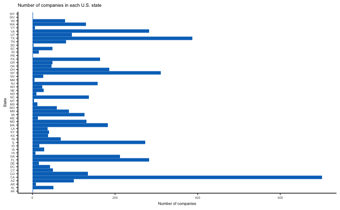

```r
ggplot(inc, aes(inc$State)) +
  geom_bar(fill = "#0073C2FF", width = 1) +
  ylab("Number of companies") +
  xlab("State") +
  ggtitle("Number of companies in each U.S. state") +
  theme(text=element_text(size=6), panel.grid.major = element_blank(), panel.grid.minor = element_blank(),panel.background = element_blank(), axis.line = element_line(colour = "black")) +
  coord_flip()
```

## Question 2

Lets dig in on the state with the 3rd most companies in the data set. Imagine you work for the state and are interested in how many people are employed by companies in different industries. Create a plot that shows the average and/or median employment by industry for companies in this state (only use cases with full data, use R’s `complete.cases()` function.) In addition to this, your graph should show how variable the ranges are, and you should deal with outliers.

The state with the 3rd most companies in the data set is NY, which has 311 of the fastest growing companies.

```r
stateCount <- as.data.frame(table(inc$State))
head(stateCount[order(-stateCount$Freq),])
```

|  | Var1 | Freq |
| --- | --- | --- |
| 5 | CA | 701 |
| 45 | TX | 387 |
| 35 | NY | 311 |
| 47 | VA | 283 |
| 10 | FL | 282 |
| 15 | IL | 273 |

Next, we remove outliers and also calculate the average number of employees by industry for these NY companies to get an idea of what numbers we’re working with. Energy and Financial Services have the highest average number of employees.

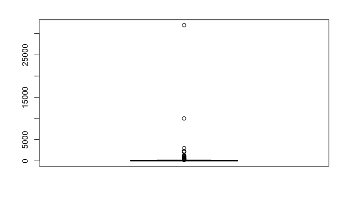

```r
#subsetting to NY companies and complete cases
ny <- inc[which(inc$State == 'NY'),]
ny <- ny[complete.cases(ny),]
#removing outliers as shown here https://stackoverflow.com/questions/53201016/remove-outliers-in-r-very-easy
b<-boxplot(ny$Employees)
```

```r
lowerwhisker<-b$stats[1]
upperwhisker<-b$stats[5]
ny <- ny[ny$Employees>lowerwhisker & ny$Employees<upperwhisker,]
indavg <- ny %>%
    group_by(Industry) %>%
    dplyr::summarize(Mean = mean(Employees))
indavg
```

| Industry | Mean |
| --- | --- |
| Advertising & Marketing | 47.07407 |
| Business Products & Services | 47.47059 |
| Computer Hardware | 44.00000 |
| Construction | 61.00000 |
| Consumer Products & Services | 40.43750 |
| Education | 59.85714 |
| Energy | 88.00000 |
| Engineering | 53.50000 |
| Environmental Services | 60.00000 |
| Financial Services | 88.00000 |

[output cut: 15 more lines]

Lastly, we graph the distributions of employee counts for fast growth companies in New York by industry. It seems like Financial Services and Energy have, on average, more employees amongst NY’s fast growth companies.

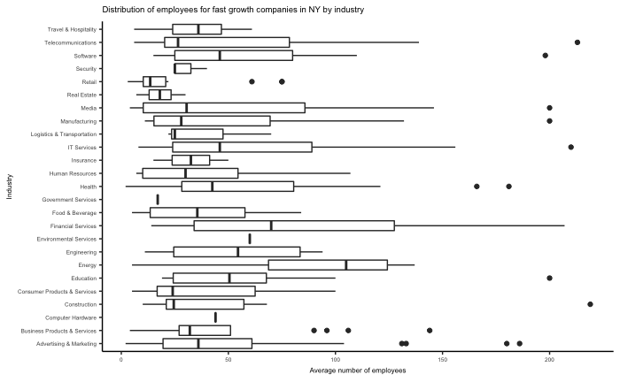

```r
ggplot(ny, aes(ny$Industry, ny$Employees)) +
  geom_boxplot() +
  ylab("Average number of employees") +
  xlab("Industry") +
  ggtitle("Distribution of employees for fast growth companies in NY by industry") +
  theme(text=element_text(size=6), panel.grid.major = element_blank(), panel.grid.minor = element_blank(),panel.background = element_blank(), axis.line = element_line(colour = "black")) +
  coord_flip()
```

```r
#ggplot(indavg, aes(indavg$Industry, indavg$Mean)) +
#  geom_bar(stat="identity", fill = "#0073C2FF", width = 1) +
#  ylab("Average number of employees") +
#  xlab("Industry") +
#  ggtitle("Average number of employees for fast growth companies in NY by industry") +
#  theme(text=element_text(size=6), panel.grid.major = element_blank(), panel.grid.minor = #element_blank(),panel.background = element_blank(), axis.line = element_line(colour = "black")) +
#  coord_flip()
```

## Question 3

Now imagine you work for an investor and want to see which industries generate the most revenue per employee. Create a chart that makes this information clear. Once again, the distribution per industry should be shown.

First, we calculate average revenue by employee for each company, and then we calculate the average of this per capita value for each industry. This uses the dataset that had already removed outliers in the number of employees.

```r
ny$revenuebyemp <- ny$Revenue / ny$Employees
indAvgRev <- ny %>%
    group_by(Industry) %>%
    dplyr::summarize(Mean = mean(revenuebyemp))
indAvgRev
```

| Industry | Mean |
| --- | --- |
| Advertising & Marketing | 380058.67 |
| Business Products & Services | 612415.10 |
| Computer Hardware | 520454.55 |
| Construction | 238694.53 |
| Consumer Products & Services | 378126.49 |
| Education | 112060.59 |
| Energy | 10564136.25 |
| Engineering | 215744.72 |
| Environmental Services | 88333.33 |
| Financial Services | 430586.48 |

[output cut: 15 more lines]

Finally, we visualize these figures in a chart. Energy generates the most revenue per employee compared to other industries for fast growth companies in NY.

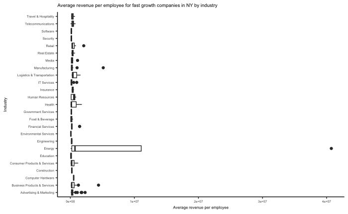

```r
ggplot(ny, aes(ny$Industry, ny$revenuebyemp)) +
  geom_boxplot() +
  ylab("Average revenue per employee") +
  xlab("Industry") +
  ggtitle("Average revenue per employee for fast growth companies in NY by industry") +
  theme(text=element_text(size=6), panel.grid.major = element_blank(), panel.grid.minor = element_blank(),panel.background = element_blank(), axis.line = element_line(colour = "black")) +
  coord_flip()
```

```r
#ggplot(indAvgRev, aes(indAvgRev$Industry, indAvgRev$Mean)) +
#  geom_bar(stat="identity", fill = "#0073C2FF", width = 1) +
#  ylab("Average revenue per employee") +
#  xlab("Industry") +
#  ggtitle("Average revenue per employee for fast growth companies in NY by industry") +
#  theme(text=element_text(size=6), panel.grid.major = element_blank(), panel.grid.minor = #element_blank(),panel.background = element_blank(), axis.line = element_line(colour = "black")) +
#  coord_flip()
```